# Compiling Parts of R

## NIMBLE training materials module

Nimble Development Team

# Using nimbleFunctions to compile R code

While nimbleFunctions are primarily designed to write algorithms to be applied to hierarchical models, you can also use nimbleFunctions as a way to compile your R code to fast C++ code without needing to write any C++ code. Note that this is unlike Rcpp, which provides tools for you to more easily write C++ code that can be called from R.

# Uses of this functionality

How might you use this functionality? Basically, this is useful for math-focused code that can't be easily vectorized.

Caveats:

- the Nimble compiler can't compile arbitrary R code, only code that is part of the Nimble DSL
- you need to give a bit of information about variable types and dimensions

# A basic demonstration

Suppose we wanted to mimic R's vectorization capabilities. Here are a couple examples. The first one is silly because we can already have R exponentiate a vector and that exponentiation happens in compiled code. The second one might seem silly, but it's not, because R will make two separate calls to compiled code and therefore run two loops, while our nimbleFunction only runs one loop.

nimbleFunctions used in this way need a run function, type and dimension information for arguments and a *returnType()* line.

```r
nimExp <- nimbleFunction(
       # run-time code for our computation
       run = function(x = double(1)) {
           returnType(double(1))
           n <- length(x)
           # Nimble needs help in determining the dimension and size of out
           declare(out, double(1))
           setSize(out, n)
           # core computation
           for( i in 1:n)
                out[i] <- exp(x[i])
           return(out)
})
```

We need the *declare()* and *setSize()* in this case (but not the next one) because it's hard for the Nimble compiler to figure out the dimension/size of *out*.

Actually nimbleFunctions can handle vectorized code using the Eigen linear algebra package, so let's consider a different implementation.

```r
nimExp2 <- nimbleFunction(
       run = function(x = double(1)) {
           returnType(double(1))
           out <- exp(x)
           return(out)
})
```

Now let's compare speed versus R.

```r
cnimExp <- compileNimble(nimExp)
cnimExp2 <- compileNimble(nimExp2)

x <- rnorm(1e6)
library(rbenchmark)
benchmark(out0 <- exp(x),
               out1 <- cnimExp(x),
               out2 <- cnimExp2(x),
               columns = c('test','replications','elapsed'),
               replications = 10)
```

```
##                  test replications elapsed
## 1      out0 <- exp(x)           10   0.292
## 2  out1 <- cnimExp(x)           10   0.393
## 3 out2 <- cnimExp2(x)           10   0.320
```

So that's not all that impressive as all we've done is match (well, not quite) the speed of the native R compiled code.

# A more involved example

Now for probit regression, we could just use standard methods to compute normal pdf integrals. But for the multinomial extension we discuss next, we need Monte Carlo simulation.

# Multinomial probit regression

# R implementation

```r
set.seed(0)
M <- 1000000
system.time({
        alphas <- c(-3, -0.5, -0.25, .1, .15, .29, .4, .45)
        K <- length(alphas)
        # generate W_k ~ N(alpha_k, 1)
        rands <- matrix(rnorm(M*K), nrow = K, ncol = M)
        props <- rep(0, K)
        tmp <- alphas + rands # exploit vectorization
        # now tally the results
        id <- apply(tmp, 2, which.max)
        tbl <- table(id)
        props[as.integer(names(tbl))] <- tbl / M
})
```

```
##    user  system elapsed
##   3.043   0.027   3.068
```

```r
mprobit <- nimbleFunction(
         run = function(alphas = double(1), M = double(0)) {
             returnType(double(1))
             K <- length(alphas)
             declare(props, double(1))
             setSize(props, K)
             declare(w, double(1))
             setSize(w, K)
             for(k in 1:K)
                   props[k] <- 0.0
             for(m in 1:M) {
                   for(k in 1:K)
                        w[k] <- alphas[k] + rnorm(1)
                   maxind <- K
                   max <- w[K]
                   for(k in 1:(K-1)) {
                        if(w[k] > max){
                                maxind <- k
                                max <- w[k]
                        }
                   }
                   props[maxind] <- props[maxind] + 1
             }
             for(k in 1:K)
                   props[k] <- props[k]/M
             return(props)
         }
)

cmprobit = compileNimble(mprobit)
set.seed(0)
system.time(
props2 <- cmprobit(alphas, M)
)
```

```
##    user  system elapsed
##   0.522   0.004   0.526
```

So we get a nice 5-fold speedup, even though all of the R code was vectorized. In the first exercise, you'll consider an example of replacing an explicit for loop in R.

# Exercises

1. Let's consider using a nimbleFunction to replace a for loop that can't be avoided in R. Write a second order random walk using a nimbleFunction. Here's the code for the R version.

```r
set.seed(0)
n <- 1e6
path <- rep(0, n)
rho1 <- .8
rho2 <- .1
path[1:2] <- rnorm(2)
print(system.time(
for(i in 3:n)
      path[i] <- rho1*path[i-1] + rho2*path[i-2] + rnorm(1)
))
```

```
##    user  system elapsed
##   3.608   0.032   3.642
```

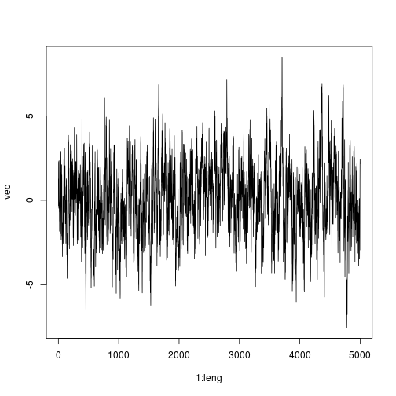

```r
tsplot(path[1:5000])
```

Now fill out the nimbleFunction version and test the timing.

```r
mc <- nimbleFunction(
   run = function( ... ) ) {
       returnType( ... )
       ...
       return(...)
})
cmc <- compileNimble(mc)
set.seed(0)
system.time(path <- cmc(n, rho1, rho2))
```

2. Generalize your code to work for an arbitrary order of dependence.
3. Use *nimStop()* as part of an error check that ensures that the length of the path to be sampled is longer than the order of the dependence.

# solution to problem 1

```r
set.seed(0)
n <- 1e6
path <- rep(0, n)
rho1 <- .8
rho2 <- .1
path[1:2] <- rnorm(2)
print(system.time(
for(i in 3:n)
      path[i] <- rho1*path[i-1] + rho2*path[i-2] + rnorm(1)
))
```

```
##    user  system elapsed
##   3.488   0.000   3.489
```

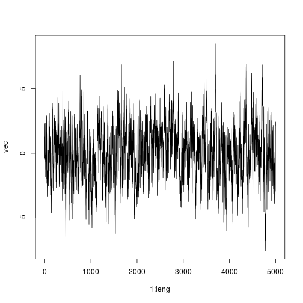

```r
tsplot(path[1:5000])
```

```r
mc <- nimbleFunction(
   run = function(n = double(0), rho1 = double(0), rho2 = double(0)) {
       returnType(double(1))
       declare(path, double(1, n))
       path[1] <- rnorm(1)
       path[2] <- rnorm(1)
       for(i in 3:n)
             path[i] <- rho1*path[i-1] + rho2*path[i-2] + rnorm(1)
       return(path)
})
cmc <- compileNimble(mc)
set.seed(0)
system.time(path <- cmc(n, rho1, rho2))
```

```
##    user  system elapsed
##   0.086   0.000   0.086
```

Not bad: going to C++ gives us a speedup of approximately 40-fold.